# EDA

Alexey Shovkun

23 сентября 2015 г.

## Загрузка данных

Считываем обучающие данные. Описание формата: В файле train.csv содержится информация для построения модели. Формат строк: признаки (x0, …, x61) и целевая переменная — y.

```
##   x0   x1   x2   x3   x4   x5   x9  x10  x11  x12  x14  x15  x16  x17  x18
##   86   16    3    3    6    7    8 1850    5    8   40    3   11   85 3351
##  x19  x20  x21  x22
##   14   87 4237    9
```

В таблице выше показано количество уникальных значений для категорийных переменных. Видим, что некоторые категорийные переменные содержат много категорий, что может затруднять процесс вставки пустых значений (imputation).

Целевую переменную (возрастнаю группа) оформляем как упорядоченную категорийную переменную (фактор).

```
##
##     0     1     2     3     4     5     6
##   361  1964 15774 14677 10012  5419  1793
```

Обучающая выборка содержит **50000** строк. Посмотрим на данные в целом.

```
##           x0                 x1                 x2
##  aa2f3cd34a:13090   16a14a2d17:48103   06330986ed:48145
##  cc73658409: 3006   bb32cb60e5:  828   9734efb986: 1383
##  467f9617a3: 1588   25e525f46c:  257   NA's      :  472
##  65d757ad7d: 1523   9ea7cf5e79:  149
##  bfff7d2d9e: 1523   16093c492a:  121
##  (Other)   :28750   (Other)   :   42
##  NA's      :  520   NA's      :  500
##           x3                 x4                 x5              x6
##  47732ccfc1:  419   16f4c50b5f:  975   1746600cb0:47980   Min.   :0.000
##  ca63304de0:49085   2351e56e34:  233   4c9789a227:  371   1st Qu.:1.000
##  NA's      :  496   8aa82606c6:  611   4f10e28b30:  949   Median :1.000
##                     a62168d626:19042   727084d214:  115   Mean   :0.993
##                     b7584c2d52:28653   e8a1d68de6:   13   3rd Qu.:1.000
##                     NA's      :  486   f81c7829f9:   62   Max.   :1.000
##                                        NA's      :  510
##        x7               x8                    x9                x10
##  Min.   :0.0000   Min.   :-85.2524   f67f142e40:16313   37eee1916c: 1074
##  1st Qu.:1.0000   1st Qu.: -0.2555   5624b8f759: 7189   abf7f8e744:  900
##  Median :1.0000   Median :  0.2210   fc150fd13a: 6844   ff3ea89708:  801
##  Mean   :0.9759   Mean   : -0.0003   7e5c97705a: 6366   2b1a0a7c41:  784
##  3rd Qu.:1.0000   3rd Qu.:  0.5676   7b1f0ca4c1: 5527   7bfe5c2f5a:  593
##  Max.   :1.0000   Max.   :  3.4268   (Other)   : 5403   (Other)   :40911
##                   NA's   :1207       NA's      : 2358   NA's      : 4937
##          x11                x12             x13                 x14
##  3d5b1dc69c: 4787   e33c63cf35:26098   Min.   :   -99   6e40247e69:22725
##  669ea3d319:13426   b38690945d:10372   1st Qu.:     0   d3e6da1933: 9576
##  91bb549494:26401   02d630ac05: 4089   Median :  1817   ff390c211c: 6346
##  a68935eb94:  475   f178803074: 3700   Mean   :  4429   fe8fb80553: 3537
##  NA's      : 4911   eed26e93c5:  367   3rd Qu.:  5582   cc69cbe29a: 2007
##                     (Other)   :  396   Max.   :776759   (Other)   : 3447
##                     NA's      : 4978   NA's   :4488     NA's      : 2362
##          x15                x16                x17
##  617a4ad3f9:42737   718c61545b:39729   c26d08129a:12123
##  eeaf83a4de: 4896   4b9480aa42: 3959   759d42196b: 5023
##  NA's      : 2367   68c96d06ae: 1755   113669f37a: 3594
##                     e8a040423a:  982   c660b9c4b6: 2790
##                     d82be38be0:  741   e84655292c: 2711
##                     (Other)   :  504   (Other)   :21409
##                     NA's      : 2330   NA's      : 2350
```

[output cut: 81 more lines]

```
##  Min.   :0.000   Min.   :0.000   Min.   :0.000   Min.   :0.000
##  1st Qu.:0.036   1st Qu.:0.008   1st Qu.:0.000   1st Qu.:0.000
##  Median :0.182   Median :0.086   Median :0.023   Median :0.000
##  Mean   :0.286   Mean   :0.202   Mean   :0.117   Mean   :0.051
##  3rd Qu.:0.481   3rd Qu.:0.304   3rd Qu.:0.130   3rd Qu.:0.025
##  Max.   :1.000   Max.   :1.000   Max.   :1.000   Max.   :1.000
##  NA's   :3874    NA's   :3874    NA's   :3874    NA's   :3874
##       x61         y
##  Min.   :   1.0   0:  361
##  1st Qu.:  37.0   1: 1964
##  Median : 105.0   2:15774
##  Mean   : 161.1   3:14677
##  3rd Qu.: 220.0   4:10012
##  Max.   :5462.0   5: 5419
##  NA's   :3874     6: 1793
```

Видим, что часть параметров являются категорийными (зашифрованные строки), причем некоторые состоят из небольшого количества категорий, а некоторые содержат большое количество разных категорий (близкое кразмеру выборки):

- x2 - 3 категрии, одна из которых пробел или пустое значение.
- х0 - потенциально большое кол-во категорий (здесь видим, что больше 6).

Также видим, что числовые поля содержат пустые значения (NA). Однако, доля пустых полей в каждом параметре отностительно невелика (<10%), поэтому не будем откидывать поля (столбцы) из-за того, что в них содержатся пустые значения. Вместо этого попробуем заместить пустые значения на непустые.

Дальнейшие действия:

1. Посмотреть на корреляцию y и параметров х0 - х60.
2. Избавиться от NA в строках. Видится 2 варианта: отдельная категория и KNN.
3. Избавиться от NA в числах. Видится 2 варианта: KNN и медиана.
4. Выполнить нормализацию

## Разведочный анализ данных

### Переменные типа integer

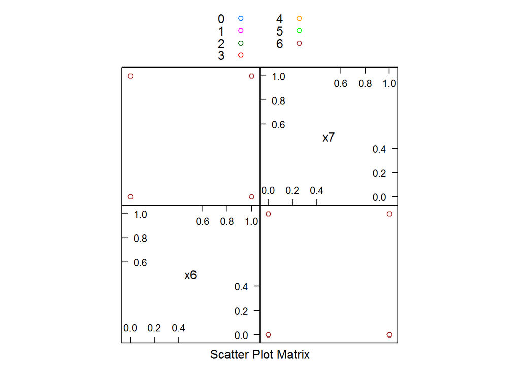

Возможно, это булевы флаги, проверим.

```
##       x7
## x6         0     1  <NA>
##   0      300    52     0
##   1      907 48741     0
##   <NA>     0     0     0
```

Действительно, эти переменные являются флагами и всегда имеют значение 0 или 1, не имеют значений NA. оформим их как категорийные переменные.

### Переменные типа numeric (действительные числа)

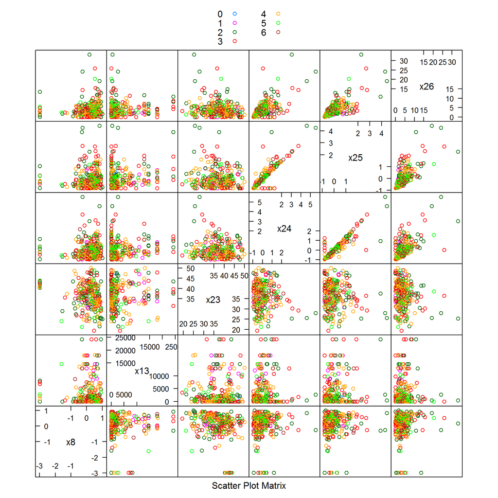

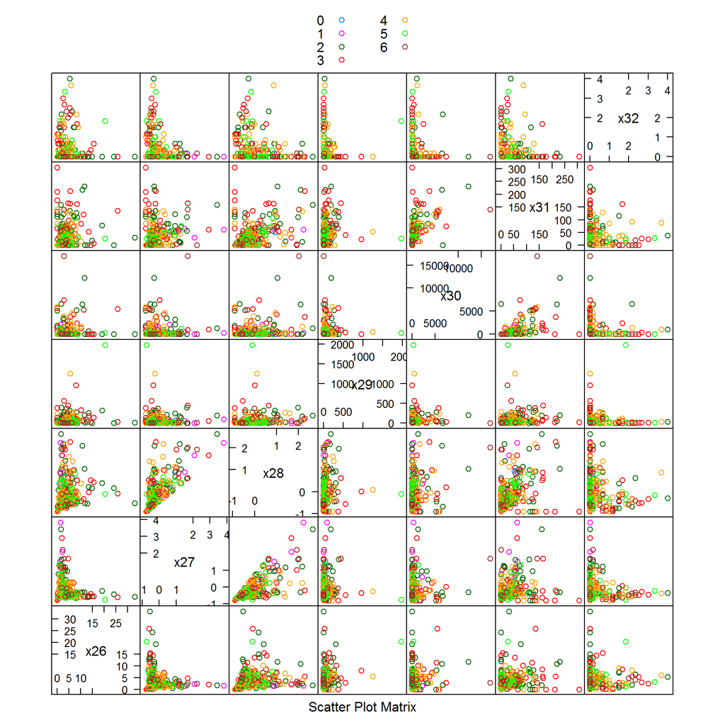

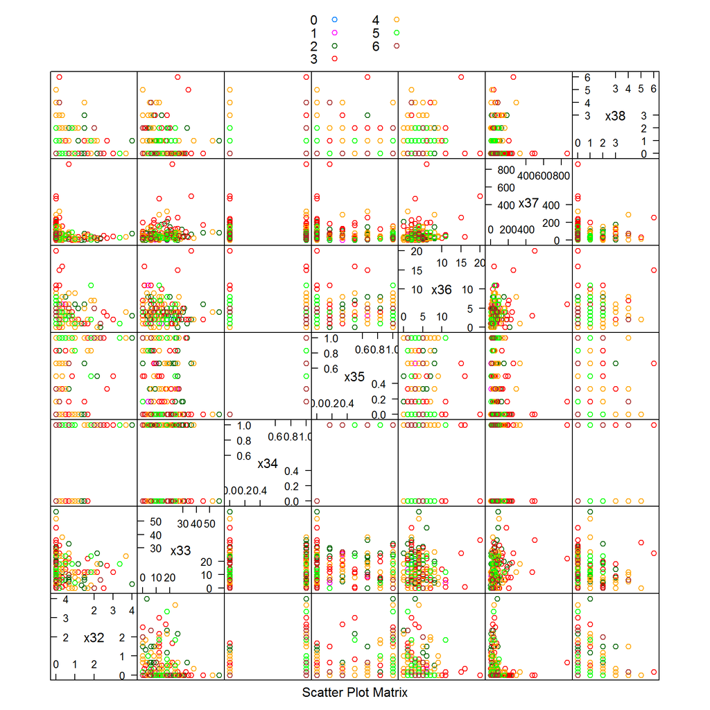

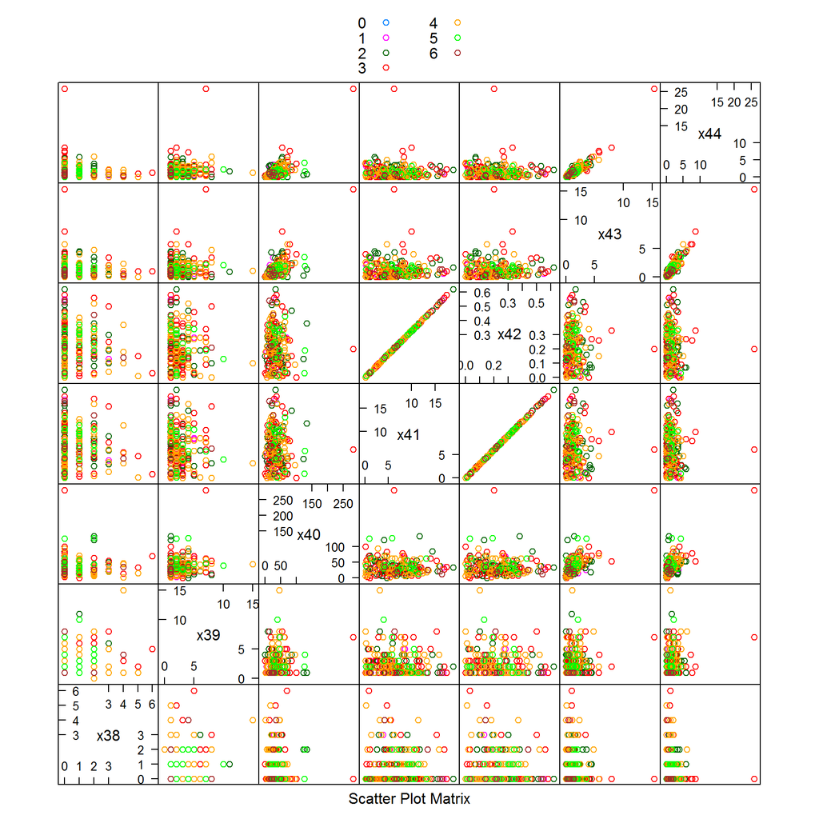

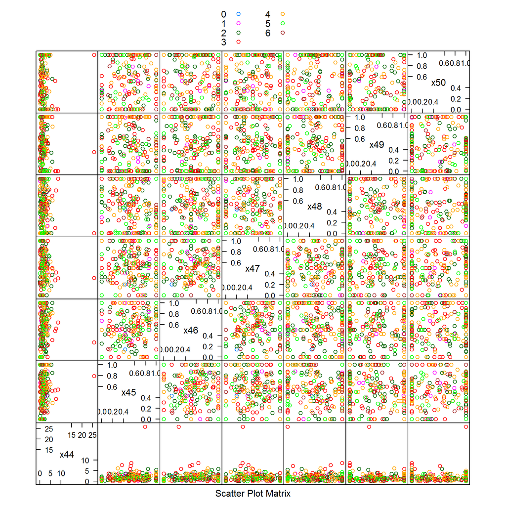

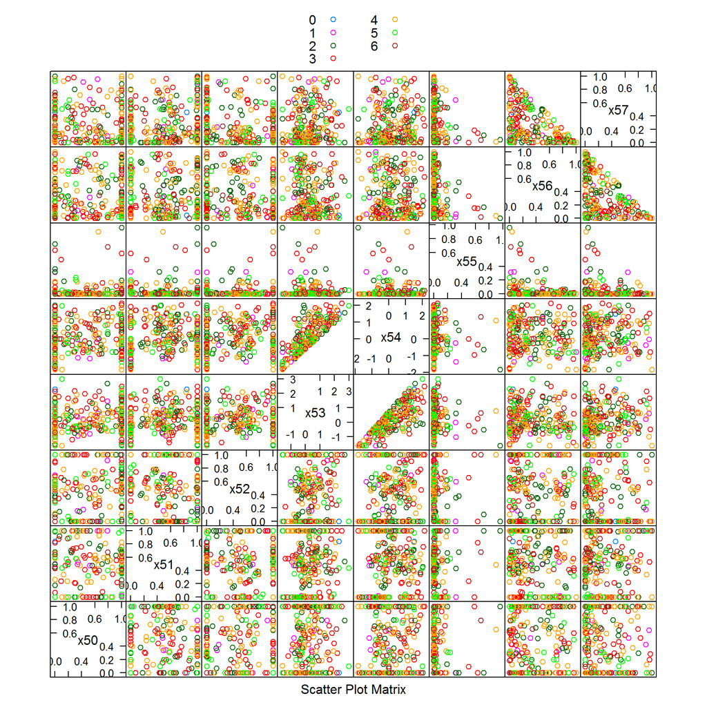

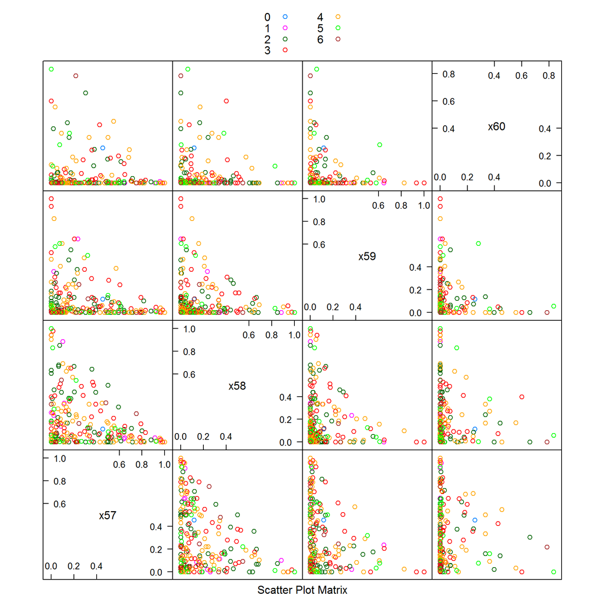

## Отбор значимых переменных

Определяем малоинформативные параметры, содержащие маленькое количество информации, т.е. имеющие в основном одинаковое значение.

```
##     freqRatio percentUnique zeroVar  nzv
## x1   58.09541         0.030   FALSE TRUE
## x2   34.81200         0.004   FALSE TRUE
## x3  117.14797         0.004   FALSE TRUE
## x5   50.55848         0.012   FALSE TRUE
## x6  141.04545         0.004   FALSE TRUE
## x7   40.42502         0.004   FALSE TRUE
## x22 236.19500         0.016   FALSE TRUE
```

Далее не будем иcпользовать эти параметры для предсказания Возрастной группы.

Проанализируем наличие коррелирующих между собой параметров. Это можно сделать только для числовых параметров?

```
##      Min.   1st Qu.    Median      Mean   3rd Qu.      Max.
## -0.427600 -0.004745  0.031830  0.059190  0.089600  0.999800
```

Задание: решить, что с ними делать. Вероятно. стоит отказаться от их использования в дальнейшем.

## Заполнение пустых значений

Подготовим два набора данных, в которых используем разные принципы заполнения пустых значений:

1. Категорийные переменные заменяем на новыу категорию “Пусто”, числовые переменные заполним константой, равной медиане. Результаты сохраним в файл **train_ConstMedian.rds**.  
   ….2. Категорийные переменные снабдим дополнительным значением и числовые переменные заполним методом К-ближайших соседей (kNN).

```
##           x0                    x1                    x2
##  aa2f3cd34a:13090   16a14a2d17   :48103   06330986ed   :48145
##  cc73658409: 3006   bb32cb60e5   :  828   9734efb986   : 1383
##  467f9617a3: 1588   Не определено:  500   Не определено:  472
##  65d757ad7d: 1523   25e525f46c   :  257
##  bfff7d2d9e: 1523   9ea7cf5e79   :  149
##  80884d4ac6: 1251   16093c492a   :  121
##  (Other)   :28019   (Other)      :   42
##              x3                    x4                    x5
##  47732ccfc1   :  419   16f4c50b5f   :  975   1746600cb0   :47980
##  ca63304de0   :49085   2351e56e34   :  233   4c9789a227   :  371
##  Не определено:  496   8aa82606c6   :  611   4f10e28b30   :  949
##                        a62168d626   :19042   727084d214   :  115
##                        b7584c2d52   :28653   e8a1d68de6   :   13
##                        Не определено:  486   f81c7829f9   :   62
##                                              Не определено:  510
##  x6        x7              x8                     x9
##  0:  352   0: 1207   Min.   :-85.25244   f67f142e40:16313
##  1:49648   1:48793   1st Qu.: -0.21217   5624b8f759: 7189
##                      Median :  0.22105   fc150fd13a: 6844
##                      Mean   :  0.00509   7e5c97705a: 6366
##                      3rd Qu.:  0.52430   7b1f0ca4c1: 5527
##                      Max.   :  3.42684   4cf172e00e: 3113
##                                          (Other)   : 4648
##             x10                   x11                   x12
##  Не определено: 4937   3d5b1dc69c   : 4787   e33c63cf35   :26098
##  37eee1916c   : 1074   669ea3d319   :13426   b38690945d   :10372
##  abf7f8e744   :  900   91bb549494   :26401   Не определено: 4978
##  ff3ea89708   :  801   a68935eb94   :  475   02d630ac05   : 4089
##  2b1a0a7c41   :  784   Не определено: 4911   f178803074   : 3700
##  7bfe5c2f5a   :  593                         eed26e93c5   :  367
##  (Other)      :40911                         (Other)      :  396
##       x13                    x14                   x15
##  Min.   :   -99   6e40247e69   :22725   617a4ad3f9   :42737
##  1st Qu.:   267   d3e6da1933   : 9576   eeaf83a4de   : 4896
##  Median :  1817   ff390c211c   : 6346   Не определено: 2367
##  Mean   :  4194   fe8fb80553   : 3537
##  3rd Qu.:  5000   Не определено: 2362
##  Max.   :776759   cc69cbe29a   : 2007
##                   (Other)      : 3447
```

[output cut: 89 more lines]

```
##  Min.   :0.00000   Min.   :0.00000   Min.   :0.00000   Min.   :0.00000
##  1st Qu.:0.04571   1st Qu.:0.04412   1st Qu.:0.01220   1st Qu.:0.00000
##  Median :0.19318   Median :0.18182   Median :0.08621   Median :0.02273
##  Mean   :0.28992   Mean   :0.27797   Mean   :0.19262   Mean   :0.10931
##  3rd Qu.:0.47085   3rd Qu.:0.44473   3rd Qu.:0.27612   3rd Qu.:0.11398
##  Max.   :1.00000   Max.   :1.00000   Max.   :1.00000   Max.   :1.00000
##
##       x60               x61         y
##  Min.   :0.00000   Min.   :   1.0   0:  361
##  1st Qu.:0.00000   1st Qu.:  41.0   1: 1964
##  Median :0.00000   Median : 105.0   2:15774
##  Mean   :0.04726   Mean   : 156.8   3:14677
##  3rd Qu.:0.01980   3rd Qu.: 206.0   4:10012
##  Max.   :1.00000   Max.   :5462.0   5: 5419
##                                     6: 1793
```

TODO:

- аналогичная обработка набора тестовых данных test.
- найти более сильный способ замены пустых значений в категорийных переменных.
- найти способ применить метод KNN к числовым переменным.